# Course-Project

## Introduction

The goal of this project is to use the HAR data set provided in the assignment to train and test a machine learning model to predict the type of activity performed. First the data is loaded, cleaned, and explored. Next, three candidate models are trained, and their in-sample error rates are compared to determine the best predictor. Finally, the best predictor is applied to the test set.

```r
library(caret)
```

## Pre-Analysis Preparation

### Loading the Data

Read the data straight into R from the links given in the assignment.

```r
train <- read.csv("https://d396qusza40orc.cloudfront.net/predmachlearn/pml-training.csv")
test <- read.csv("https://d396qusza40orc.cloudfront.net/predmachlearn/pml-testing.csv")
```

### Cleaning and Pre-processing

First, check for for NA values and blank character values, since they need to be dealt with before most machine learning tools can be applied.

```r
checkContent <- function(x) {
  if (is.character(x)) {
    return(mean(x==""))
  } else {
    return(mean(is.na(x)))
  }
}
table(sapply(train, checkContent))
```

```
##
##                 0 0.979308938946081
##                60               100
```

```r
train <- train[, sapply(train, function(x) checkContent(x)==0)]
```

Next, check the types of the features remaining, and look at the head of the character variables to see if they still hold any useful information.

```r
table(sapply(train, class))
```

```
##
## character   integer   numeric
##         4        29        27
```

```r
head(train[, sapply(train, function(x) !is.numeric(x))], n=3)
```

```
##   user_name   cvtd_timestamp new_window classe
## 1  carlitos 05/12/2011 11:23         no      A
## 2  carlitos 05/12/2011 11:23         no      A
## 3  carlitos 05/12/2011 11:23         no      A
```

There’s the “classe” feature to be predicted, which is extremely important, but the others (user_name, cvtd_timestamp, new_window) seem unlikely to be of predictive value. Remove from data set.

```r
train <- train[, -which(names(train) %in% c("user_name", "cvtd_timestamp", "new_window"))]
```

### Exploratory Analysis

Examine the correlation matrix for the predictor features, which are now all numeric, to check for patterns or major groups of correlated variables.

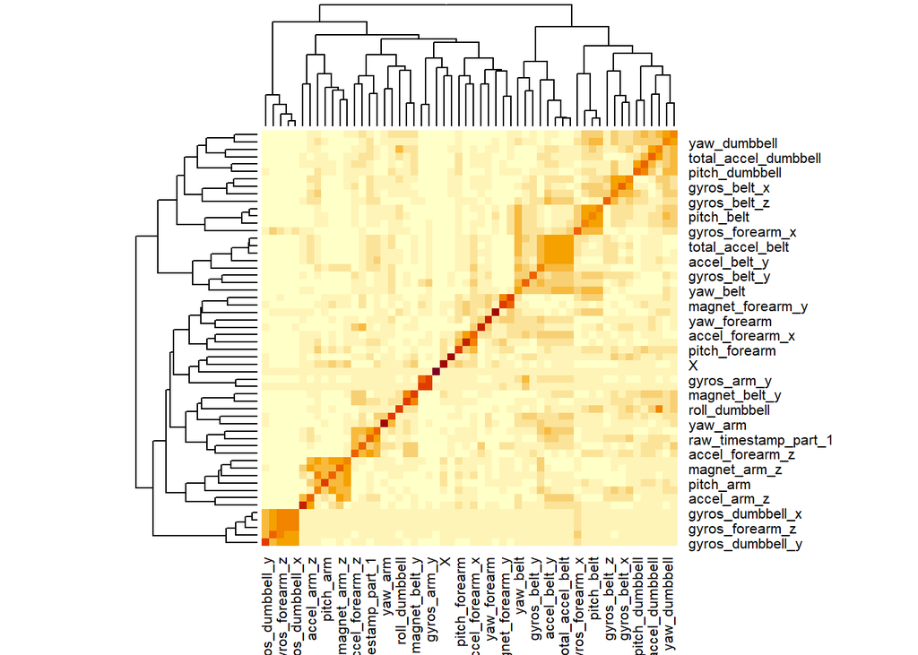

```r
heatmap(abs(cor(train[, sapply(train, is.numeric)])))
```

There are some small, somewhat correlated groups, but no major trends.

## Modeling

### Training

This is a supervised classification problem, so candidates include methods such as random forest, linear discriminant, and gradient boosting models. Train candidate models using 10-fold cross-validation to further improve accuracy, and excluding the “X” feature, which simply indexes all entries.

Broken up into separate chunks because oh boy does this take a while.

```r
trctrl <- trainControl(method="cv", number=10)
rf <- train(classe~.-X, data=train, method="rf", trControl=trctrl)
```

```r
lda <- train(classe~.-X, data=train, method="lda", trControl=trctrl)
```

```r
gbm <- train(classe~.-X, data=train, method="gbm", trControl=trctrl)
```

### In Sample Accuracy

Check in-sample accuracy rates, to determine which candidate model is best.

```r
confusionMatrix(predict(rf, train), factor(train$classe))$overall
```

```
##       Accuracy          Kappa  AccuracyLower  AccuracyUpper   AccuracyNull
##      1.0000000      1.0000000      0.9998120      1.0000000      0.2843747
## AccuracyPValue  McnemarPValue
##      0.0000000            NaN
```

```r
confusionMatrix(predict(lda, train), factor(train$classe))$overall
```

```
##       Accuracy          Kappa  AccuracyLower  AccuracyUpper   AccuracyNull
##   7.196004e-01   6.450737e-01   7.132577e-01   7.258781e-01   2.843747e-01
## AccuracyPValue  McnemarPValue
##   0.000000e+00  3.613112e-185
```

```r
confusionMatrix(predict(gbm, train), factor(train$classe))$overall
```

```
##       Accuracy          Kappa  AccuracyLower  AccuracyUpper   AccuracyNull
##      0.9987769      0.9984529      0.9981806      0.9992162      0.2843747
## AccuracyPValue  McnemarPValue
##      0.0000000            NaN
```

## Testing

### Test Cases

Use the most accurate model to predict the “classe” for the test cases in the “test” dataset. Given how high the in-sample accuracy is, it seems possible that the model is somewhat overtrained. Out-of-sample accuracy is also usually lower in general, so 90-95% seems like a reasonable estimate.

```r
predict(rf, test)
```

```
##  [1] B A B A A E D B A A B C B A E E A B B B
## Levels: A B C D E
```